# DIPnet Population Structure Notebook

# Setup

```r
library(seqinr)
library(ape)
library(pegas)
library(hierfstat)
library(mmod)
library(adegenet)
library(plyr)
library(strataG)
library(iNEXT)
library(gdm)
library(gdistance)
library(ecodist)
library(dplyr)
library(reshape2)
library(WriteXLS)
library(ggplot2)
library(knitr)
library(vegan)
library(gridExtra)
library(data.table)


source("config.R")
source("DIPnet_Stats_Functions.R")

rescale<-function(x){
  normalized<-(x-min(x))/(max(x)-min(x))
  return(normalized)
}

remove.dup.gsls<-function(amovatable){
  amovatable<-amovatable[-which(rownames(amovatable) %in% dups),]
}
```

```r
taxorder<-read.csv("DIPnet_Species_Class.csv")
#duplicate GSLs that need to be dropped
dups<-c("Acanthaster_planciSIO_CR","Acanthaster_planciRedSea_CR","Acanthaster_planciNIO_CR","Acanthaster_planciPac_CR","Acanthurus_nigrofuscus_CO1","Cephalopholis_argus_CO1","Chaetodon_auriga_CO1","Halichoeres_claudia_CR","Halichoeres_hortulanus_CO1","Halichoeres_hortulanus_CYB","Halichoeres_trimaculatus_CR","Lutjanus_kasmira_CO1","Naso_hexacanthus_CR","Neoniphon_sammara_CO1","Pomacentrus_coelestis_CO1","Pygoplites_diacanthus_CYB", "Stenella_longirostris_CYB")
hypotheses<-c("Bowen","Keith","Kulbicki_r","Kulbicki_b","REALM","PROVINCE","ECOREGION", "VeronDivis")
# Remove dups
ipdb_ip<-ipdb_ip[!ipdb_ip$Genus_species_locus %in% c(dups,"Ctenochaetus_marginatus_A68"),]
```

# Introduction

The overall workflow for this analysis is as follows:

- Run AMOVA according to several different regionalizations
  - Briggs and Bowen 2013 - Fish Biogeography
  - Veron et al. 2015 - Coral Biogeography
  - Spalding et al. 2007 -
    - Marine Ecoregions
    - Provinces
    - Realms
  - Kulbicki et al. 2013 -
    - Regionalization based on all species,
    - or just “reliable” species
  - Keith et al. 2013 - Faunal Breaks
- Select the best model for each species according to the Bayesian Information Criterion
- Analyze individual “barriers” as implied by the regionalization that best explains the distribution of variation in the most species by modeling pairwise genetic distances given geographic distance and each barrier (individually or together):
  - Distance Based Redundancy Analysis (dbRDA)

# Run AMOVA loops

Given the special considerations, we need to run 4 different flavors of AMOVA: 1. WCTheta and TradSpec 2. WCTheta and ABGD 3. PhiST and TradSpec 4. PhiST and ABGD

Thus, we need to loop through all of the regionalizations above, running all 4 flavors of AMOVA.

```r
## Loop through hypotheses, calculating AMOVA
hypotheses<-c("Kulbicki_r","REALM","Bowen","Kulbicki_b","Keith", "VeronDivis","PROVINCE","ECOREGION")
amova_list<-list()

for(h in hypotheses){
  hierstats<-hierarchical.structure.mtDNA.db(ipdb = ipdb_ip,level1 = "sample",level2=h,model="N",ABGD=F,nperm=1)
  amova_list[[h]]<-hierstats
}

#load(file.path(amova_ts_path,"PHIST_TradSpecies_raw_amova_output.Rdata"))
## Summarize AMOVA results
amovastats<-summarize_AMOVA(amova_list,hypotheses,specieslist=unique(ipdb$Genus_species_locus))

WriteXLS(amovastats,ExcelFileName=file.path(amova_ts_path,"PHIST_ts_rawN_table_amova_output.Rdata.xlsx"),row.names = T)
save(amova_list,file=file.path(amova_ts_path,"PHIST_ts_rawN_amova_output.Rdata"))
save(amovastats,file=file.path(amova_ts_path,"PHIST_ts_tableN_amova_output.Rdata"))
```

This takes a long time, so we are not running this code in the document, but loading in the results as we go through each consideration

# Visualize AMOVA results

## PHIST and Traditional Species Boundaries

### Measure Support

```r
load(file=file.path(amova_ts_path,"PHIST_ts_tableN_amova_output.Rdata"))
#load(file=file.path(amova_ts_path,"FST_TradSpec_table_amova_output.Rdata"))
#remove duplicate gsls
amovastats<-lapply(amovastats,remove.dup.gsls)
# Measure support for each hypothesis
#Get the values for each hypothesis for a given criterion - here I use BIC - and rank them for #each species, then choose the "best" hypothesis for each species based on the criterion.
criterion<-"BIC"
# find the maximum number of species from any of the 8 hypotheses
maxlength<-max(sapply(amovastats,function(x) length(x[[1]])))
# create an empty data frame with row names from the hypothesis with the most values
crit_df<-data.frame(setNames(replicate(maxlength,numeric(0), simplify = F),nm=row.names(amovastats[["PROVINCE"]])))
#Loop through the hypotheses, pulling out the values for criterion,transpose it, and then merge these values into the dataframe from the previous hypothesis
for(h in names(amovastats)){
  crit_df<-merge(crit_df,t(amovastats[[h]][criterion]),all=T,sort=F)
}
#get the hypothesis names in there
row.names(crit_df)<-names(amovastats)
#rank the hypotheses for each species
crit_rank<-as.data.frame(sapply(crit_df,rank,na.last="keep",ties.method="average"))
row.names(crit_rank)<-names(amovastats)
## remove gsls with more than 3 missing models
crit_rank<-crit_rank[, colSums(is.na(crit_rank)) < nrow(crit_rank)-4]
## choose the best hypothesis or set of hypotheses for each species
best_hypothesis<-sapply(crit_rank,function(x){row.names(crit_rank)[which(x==min(x,na.rm=T)) ]})
# Convert to Data Frame
best_hypothesis<-as.data.frame(unlist(best_hypothesis))
best_hypothesis$Genus_species_locus<-row.names(best_hypothesis)
#some grepping to get the extra numbers off the ends of gsl names
best_hypothesis$Genus_species_locus<-gsub("(\\w+_\\w+_CR)", replacement="\\1R",best_hypothesis$Genus_species_locus, perl=T)
best_hypothesis$Genus_species_locus<-gsub("(\\w+_\\w+_\\w\\w\\w)\\w", replacement="\\1", best_hypothesis$Genus_species_locus, perl=T)
best_hypothesis$Genus_species_locus<-gsub("(\\w+_\\w+_CR)R", replacement="\\1", best_hypothesis$Genus_species_locus, perl=T)
best_hypothesis<-left_join(best_hypothesis, taxorder[,8:9], by="Genus_species_locus")
```

```
Column `Genus_species_locus` joining character vector and factor, coercing into character vector
```

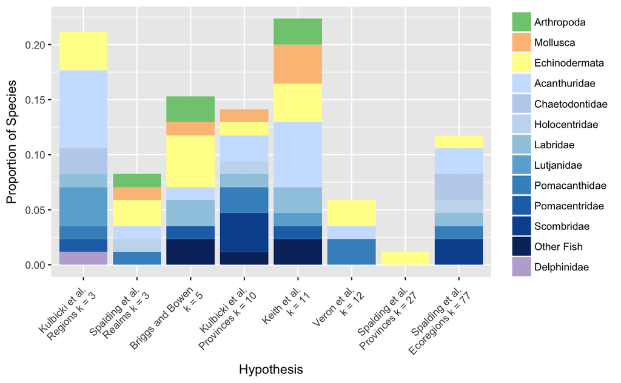

```r
names(best_hypothesis)[1]<-"Hypothesis"
#Order the levels of "Taxon"
best_hypothesis$Taxon<-factor(best_hypothesis$Taxon,levels=c("Arthropoda","Mollusca","Echinodermata","Acanthuridae","Chaetodontidae","Holocentridae","Labridae","Lutjanidae","Pomacanthidae","Pomacentridae","Scombridae","Other Fish","Delphinidae"))
# make a custom palette
library(RColorBrewer)
blue<-brewer.pal(9,"Blues")
cols<-c("#7FC97F","#FDC086","#FFFF99","#CDE2FF","#BFD1EC",blue[3:9],"#BEAED4")
#remove Tridacna costata because according to Marc Kochzius, this is actually T. crocea data
best_hypothesis<-best_hypothesis[-77,]

## Make a bar graph of best support for each hypothesis among species
barplot<-ggplot(data=best_hypothesis, aes(x=Hypothesis,fill=Taxon )) + geom_bar(aes(y = (..count..)/sum(..count..))) +
   scale_x_discrete(limits=hypotheses, labels=c("Kulbicki et al. \n Regions k = 3","Spalding et al. \n Realms k = 3","Briggs and Bowen \n k = 5","Kulbicki et al. \n Provinces k = 10","Keith et al. \n k = 11","Veron et al. \n k = 12",  "Spalding et al. \n Provinces k = 27" , "Spalding et al. \n Ecoregions k = 77")) +
  labs(x="Hypothesis",y="Proportion of Species") + theme(axis.text.x = element_text(angle = 45, hjust = 1), legend.title=element_blank()) + scale_fill_manual(values=cols)
barplot
```

### Calculate relative probability from Johnson and Omland 2004

```r
# lookup the minimum BIC value for each species (which.min works better here, because it returns only the first instance of the minimum value)
minBIC<-sapply(crit_df,function(x){x[which.min(x)]})
#J&O box 4 eqn 1. scale() seems to be the way to go here, using the minBIC as the centering vector
crit_df_deltaI<-scale(crit_df, center=minBIC, scale=F)
#J&O box 4 eqn 4. numerator, plus make it a data frame
crit_df_deltaI_b<-as.data.frame(exp(-0.5*crit_df_deltaI))
#J&O box 4 eqn 4. denominator
crit_df_deltaI_sums<-sapply(crit_df_deltaI_b,sum,na.rm=T)
# this time use the scale argument of scale to divide each column by the corresponding sum
crit_df_relative_prob<-scale(crit_df_deltaI_b,center=F,scale=crit_df_deltaI_sums)
# Now zap all GSLs that test less than 5 hypotheses
naCount<-colSums(is.na(crit_df_relative_prob))
na4<-names(naCount)[which(naCount<4)]
crit_df_relative_prob_na4<-crit_df_relative_prob[,na4]
#remove Tridacna costata because Kochzius says this is actually T. crocea data
crit_df_relative_prob_na4<-crit_df_relative_prob_na4[,-51]
```

There are 57 GSLs that test at least 5 hypotheses

### Heatmap

So now make a trimmed heatmap of just these.

```r
## Make a new heatmap of relative probability of each hypothesis
#melt for ggplot2
relprob<-melt(crit_df_relative_prob_na4)
colnames(relprob)<-c("Hypothesis","Species","Relative_Probability")
#make names
spnames<-sub("(\\w+)_(\\w+)_(\\w+)","\\1 \\2 \\3",na4, perl=T)
spnames<-sort(spnames)
#sort taxonomically
relprob$Species<-factor(relprob$Species,levels=taxorder$Genus_species_locus)
#baseplot
rp<-ggplot(relprob,aes(y=Species,x=Hypothesis,fill=Relative_Probability))
#add geom_tile, turn the x-axis elements by 90 degrees, reverse the names on the y-axis, and use a diverging color scheme to highlight hypotheses with >50% rel prob.
rp<-rp+geom_tile()+
  theme(axis.text.x = element_text(angle = 90, hjust = 1))+
  scale_fill_gradient(low = "white",
                       high = "red", space = "rgb",
                       na.value = "grey50", guide = "colourbar") +
  scale_x_discrete(limits=hypotheses, labels=c("Kulbicki et al. \n Regions k = 3","Spalding et al. \n Realms k = 3","Briggs and Bowen \n k = 5","Kulbicki et al. \n Provinces k = 10","Keith et al. \n k = 11","Veron et al. \n k = 12",  "Spalding et al. \n Provinces k = 27" , "Spalding et al. \n Ecoregions k = 77")) +
  scale_y_discrete(limits=rev(levels(relprob$Species)), labels=sub("(\\w+)_(\\w+)_(\\w+)","\\1 \\2 \\3",rev(levels(relprob$Species)), perl=T))
```

```
Non Lab interpolation is deprecated
```

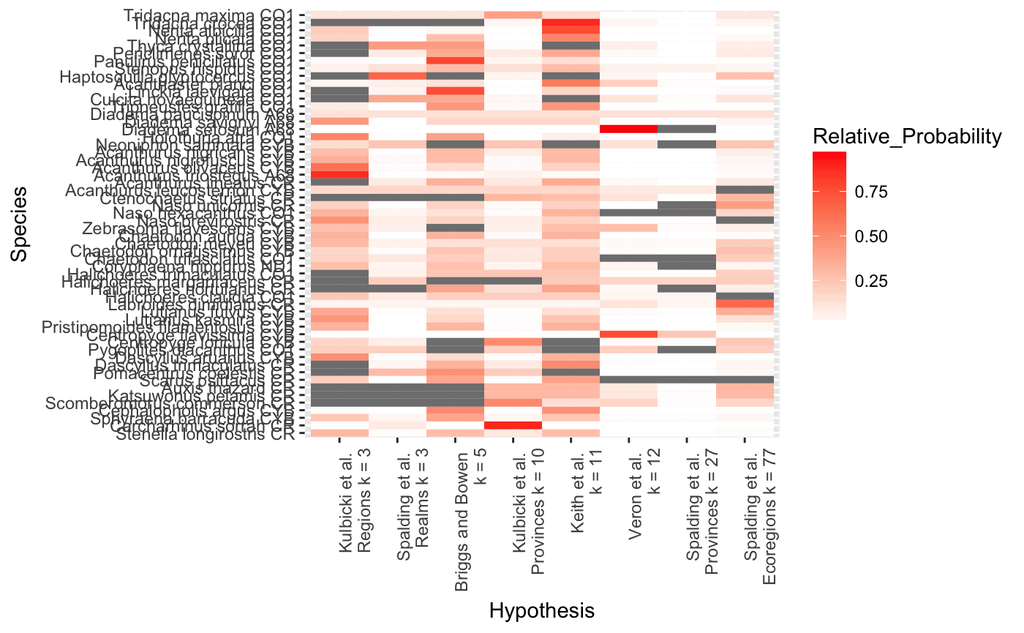

```r
rp
```

```r
#save this from the viewer
#ggsave("./output/PhiST_Heatmap_Final.pdf", rp)
```

### Calculate Effect Sizes

#### PHICT

```r
FCTs<-NULL
for(h in hypotheses){
  FCT<-amovastats[[h]]$FCT
  FCTs[[h]]<-FCT
}
FCTsmelt<-melt(FCTs)
ggplot(FCTsmelt,aes(x=L1, y=value)) + geom_boxplot() + scale_x_discrete(limits=hypotheses, labels=c("Kulbicki et al. \n Regions k = 3","Spalding et al. \n Realms k = 3","Briggs and Bowen \n k = 5","Kulbicki et al. \n Provinces k = 10","Keith et al. \n k = 11","Veron et al. \n k = 12",  "Spalding et al. \n Provinces k = 27" , "Spalding et al. \n Ecoregions k = 77")) + theme(axis.text.x = element_text(angle = 90, hjust = 1))+
                                        ylab("Phi_CT") + xlab("Regionalization")
lapply(FCTs,mean)
```

[output not shown]

```
$Bowen
[1] 0.1765181

$Keith
[1] 0.1856604

$Kulbicki_r
[1] 0.1802033

$Kulbicki_b
[1] 0.1215307

$REALM
[1] 0.1694083

$PROVINCE
[1] 0.2315482

$ECOREGION
[1] 0.2105467

$VeronDivis
[1] 0.1476603
```

```r
effect<-data.frame(setNames(replicate(maxlength,numeric(0), simplify = F),nm=row.names(amovastats[["PROVINCE"]])))
for(h in names(amovastats)){
 # effect<-merge(effect,t(amovastats[[h]]["level2_SSD"]/amovastats[[h]]["total_SSD"]),all=T,sort=F) #rsquared or etasquared
  effect<-merge(effect,t(amovastats[[h]]["FCT"]),all=T,sort=F)
}
row.names(effect)<-names(amovastats)
effect$model<-rownames(effect)
effectsize<-melt(effect)
colnames(effectsize)<-c("Hypothesis","Species","Effect_Size")
#baseplot
ef<-ggplot(effectsize,aes(y=Species,x=Hypothesis,fill=Effect_Size))
#add geom_tile, turn the x-axis elements by 90 degrees, reverse the names on the y-axis, and use a diverging color scheme to highlight hypotheses with >50% rel prob.
ef<-ef+geom_tile()+
  theme(axis.text.x = element_text(angle = 90, hjust = 1))+
  scale_fill_gradient2(low = "blue",mid="white",
                       high = "red", space = "rgb",
                       na.value = "grey50", guide = "colourbar") +
  scale_x_discrete(limits=hypotheses, labels=c("Kulbicki et al. \n Regions k = 3","Spalding et al. \n Realms k = 3","Briggs and Bowen \n k = 5","Kulbicki et al. \n Provinces k = 10","Keith et al. \n k = 11","Veron et al. \n k = 12",  "Spalding et al. \n Provinces k = 27" , "Spalding et al. \n Ecoregions k = 77")) +
  scale_y_discrete(limits=rev(levels(effectsize$Species)), labels=sub("(\\w+)_(\\w+)_(\\w+)","\\1 \\2 \\3",rev(levels(effectsize$Species)), perl=T))
```

```
Non Lab interpolation is deprecated
```

```r
effect$model<-NULL
#Change all values to negative so that rank() treats them appropriately
effectneg<-as.data.frame(sapply(effect,function(x){return(x*-1)}))
rownames(effectneg)<-rownames(effect)
#rank the hypotheses for each species
effect_rank<-as.data.frame(sapply(effectneg,rank,na.last="keep",ties.method="average"))
rownames(effect_rank)<-rownames(effectneg)
## remove gsls with more than 3 missing models
effect_rank<-effect_rank[, colSums(is.na(effect_rank)) < nrow(effect_rank)-4]
## choose the best hypothesis or set of hypotheses for each species
best_hypothesis<-sapply(effect_rank,function(x){row.names(effect_rank)[which(x==min(x,na.rm=T)) ]})
# Convert to Data Frame
best_hypothesis<-as.data.frame(unlist(best_hypothesis))
best_hypothesis$Genus_species_locus<-row.names(best_hypothesis)
#some grepping to get the extra numbers off the ends of gsl names
best_hypothesis$Genus_species_locus<-gsub("(\\w+_\\w+_CR)", replacement="\\1R",best_hypothesis$Genus_species_locus, perl=T)
best_hypothesis$Genus_species_locus<-gsub("(\\w+_\\w+_\\w\\w\\w)\\w", replacement="\\1", best_hypothesis$Genus_species_locus, perl=T)
best_hypothesis$Genus_species_locus<-gsub("(\\w+_\\w+_CR)R", replacement="\\1", best_hypothesis$Genus_species_locus, perl=T)
best_hypothesis<-left_join(best_hypothesis, taxorder[,8:9], by="Genus_species_locus")
```

```
Column `Genus_species_locus` joining character vector and factor, coercing into character vector
```

```r
names(best_hypothesis)[1]<-"Hypothesis"
#Order the levels of "Taxon"
best_hypothesis$Taxon<-factor(best_hypothesis$Taxon,levels=c("Arthropoda","Mollusca","Echinodermata","Acanthuridae","Chaetodontidae","Holocentridae","Labridae","Lutjanidae","Pomacanthidae","Pomacentridae","Scombridae","Other Fish","Delphinidae"))
# make a custom palette
library(RColorBrewer)
blue<-brewer.pal(9,"Blues")
cols<-c("#7FC97F","#FDC086","#FFFF99","#CDE2FF","#BFD1EC",blue[3:9],"#BEAED4")

## Make a bar graph of best support for each hypothesis among species
barplot<-ggplot(data=best_hypothesis, aes(x=Hypothesis,fill=Taxon )) + geom_bar(aes(y = (..count..)/sum(..count..))) +
   scale_x_discrete(limits=hypotheses, labels=c("Kulbicki et al. \n Regions k = 3","Spalding et al. \n Realms k = 3","Briggs and Bowen \n k = 5","Kulbicki et al. \n Provinces k = 10","Keith et al. \n k = 11","Veron et al. \n k = 12",  "Spalding et al. \n Provinces k = 27" , "Spalding et al. \n Ecoregions k = 77")) +
  labs(x="Hypothesis",y="Proportion of Species") + theme(axis.text.x = element_text(angle = 45, hjust = 1), legend.title=element_blank()) + scale_fill_manual(values=cols)
barplot
```

[output not shown]

#### Sigma^2a (level2_sigma2)

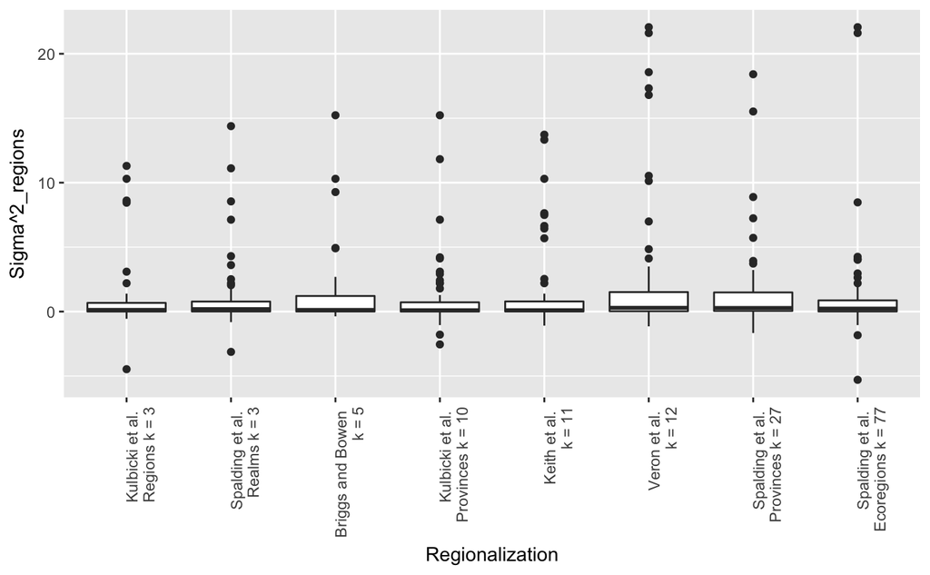

```r
sigma_as_melt<-melt(sigma_as)
ggplot(sigma_as_melt,aes(x=L1, y=value)) + geom_boxplot() + scale_x_discrete(limits=hypotheses, labels=c("Kulbicki et al. \n Regions k = 3","Spalding et al. \n Realms k = 3","Briggs and Bowen \n k = 5","Kulbicki et al. \n Provinces k = 10","Keith et al. \n k = 11","Veron et al. \n k = 12",  "Spalding et al. \n Provinces k = 27" , "Spalding et al. \n Ecoregions k = 77")) + theme(axis.text.x = element_text(angle = 90, hjust = 1))+
                                        ylab("Sigma^2_regions") + xlab("Regionalization")
lapply(sigma_as,mean)
```

```
$Bowen
[1] 1.161145

$Keith
[1] 1.189499

$Kulbicki_r
[1] 1.342074

$Kulbicki_b
[1] 0.8989921

$REALM
[1] 1.567145

$PROVINCE
[1] 2.265113

$ECOREGION
[1] 1.463144

$VeronDivis
[1] 1.228361
```

## FST and Traditional Species Boundaries

### Measure Support

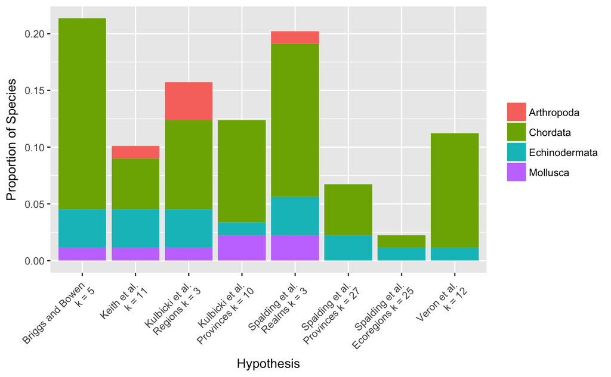

### Calculate relative probability from Johnson and Omland 2004 and visualize with a heatmap

```
Non Lab interpolation is deprecated
```

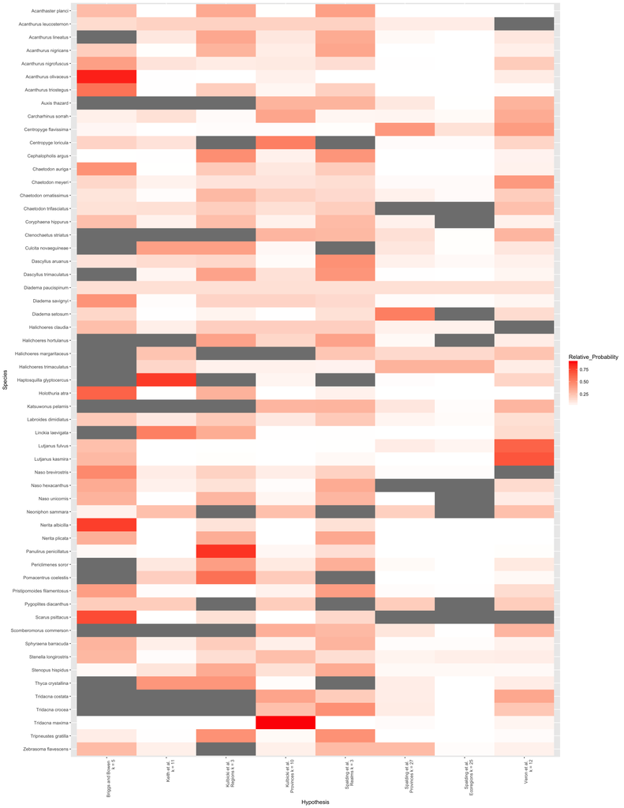

# Calculate Pairwise Differentiation Stats

By sample

```r
diffstats<-pairwise.structure.mtDNA.db(ipdb=ipdb, gdist = "WC Theta", minseqs = 5, minsamps = 3, mintotalseqs = 0, nrep = 0, num.cores = 2, ABGD = T, regionalization = "sample")


save(diffstats, file="/Users/eric/google_drive/DIPnet_Gait_Lig_Bird/DIPnet_WG4_first_papers/statistics/By_ESU/Pairwise_statistics/DIPnet_structure_sample_WCTheta_ABGD.Rdata")

diffstats<-pairwise.structure.mtDNA.db(ipdb=ipdb, gdist = "Jost D", minseqs = 5, minsamps = 3, mintotalseqs = 0, nrep = 0, num.cores = 2, ABGD = T, regionalization = "sample")


save(diffstats, file="/Users/eric/google_drive/DIPnet_Gait_Lig_Bird/DIPnet_WG4_first_papers/statistics/By_ESU/Pairwise_statistics/DIPnet_structure_sample_JostD_ABGD.Rdata")
```

# Mixing Bowen and Spalding Realms

First step is to distinguish Hawaii, Easter Island and the Marquesas, thereby mixing in a little bit of Briggs and Bowen

```r
unique(ipdb_ip$Bowen)
```

```
[1] "Indo-Polynesian"               "Hawaiian"                      "Western Indian Ocean Province"
[4] "Marquesas"                     "Easter"
```

```r
unique(ipdb_ip$REALM)
```

```
[1] "Central Indo-Pacific" "Eastern Indo-Pacific" "Western Indo-Pacific"
```

```r
dim(ipdb_ip)
```

```
[1] 29087   112
```

```r
ipdb_ip$REALM[which(ipdb_ip$Bowen=="Hawaiian")]<-"Hawaii"
ipdb_ip$REALM[which(ipdb_ip$Bowen=="Marquesas")]<-"Marquesas"
ipdb_ip$REALM[which(ipdb_ip$Bowen=="Easter")]<-"Easter"
ipdb_ip$REALM[which(ipdb_ip$Bowen=="Western Indian Ocean Province")]<-"Western Indian Ocean Province"
unique(ipdb_ip$REALM)
```

```
[1] "Central Indo-Pacific"          "Eastern Indo-Pacific"          "Hawaii"
[4] "Western Indo-Pacific"          "Western Indian Ocean Province" "Marquesas"
[7] "Easter"
```

# dbRDA

```r
# read in the Fst/PhiSt table
load("~/google_drive/DIPnet_Gait_Lig_Bird/DIPnet_WG4_first_papers/statistics/By_Species/Pairwise_statistics/sample/DIPnet_structure_sample_PhiST.Rdata")
#load("~/Desktop/DIPnet_structure_sample_PhiST_042817.Rdata")

# read in the best hypotheses
best_hypotheses<-read.csv("best_hypothesis.csv")

##1. Dataframe for results
stats<-data.frame(Species_Locus=character(0),constrained.inertia=numeric(0),totalInertia=numeric(0),ProportionConstrained=numeric(0),adj.R2.total=numeric(0),modelF=numeric(0),modelPvalue=numeric(0),pcx_Var=numeric(0),pcx_p=numeric(0),pcy_Var=numeric(0),pcy_p=numeric(0),bestmodel=character(0), constrained.inertia.best=numeric(0), total.inertia.best=numeric(0), proportion.constrained.inertia.best=numeric(0), adj.R2.best.model=numeric(0), stringsAsFactors = F)
stats$Species_Locus<-as.character(stats$Species_Locus)
#stats$Barrier<-as.character(stats$Barrier)
stats$bestmodel<-as.character(stats$bestmodel)

plotlist<-list()

# Make an empty list to save rda output for each species
esu_loci <- na4
all.gsl.rda<-sapply(esu_loci, function(x) NULL)

#make empty data frames to save variance and pvalues
term.vars<-data.frame(gsl=character(0))
term.pvals<-data.frame(gsl=character(0))

###############################################################################
# 2. Subsample for each species of interest, and filter based on Phi_ST table.
for(gsl in esu_loci){ #gsl<-"Linckia_laevigata_CO1" "Tridacna_crocea_CO1" "Lutjanus_kasmira_CYB"

  cat("\n","\n","\n","Now starting", gsl, "\n")

  #lookup the best hypothesis
  #best_h<-as.character(best_hypotheses[which(gsl==best_hypotheses$gsl),2])
  best_h<-"REALM"
#  if(any(is.na(diffstats[[gsl]]))){cat("NAs in FST table, No dbRDA calculated"); #all.gsl.rda[[gsl]]<-"NAs in FST table, No dbRDA calculated"; next}

  #replace NAs with 1s. NAs occur when no haplotypes are shared.
   if(any(is.na(diffstats[[gsl]]))){
    diffstats[[gsl]][which(is.na(diffstats[[gsl]]))]<-1
  }

  if(diffstats[[gsl]]=="Fewer than 3 sampled populations after filtering. No stats calculated"){all.gsl.rda[[gsl]]<-"Fewer than 4 sampled populations after filtering."; cat("Fewer than 4 sampled populations after filtering.");next}

   sp<-ipdb_ip[which(ipdb_ip$Genus_species_locus==gsl),]

  #clean weird backslashes from names
  sp$locality<-gsub("\"","",sp$locality)

  sp$sample<-paste(sp$locality,round(sp$decimalLatitude, digits=0),round(sp$decimalLongitude, digits=0),sep="_")  #sets up a variable that matches the name in Fst table
  sp<-sp[order(sp$sample),]
  # Not all localities are included in every realization - zap the ones that are NA
  #nonpops<-unique(sp$sample[is.na(sp$REALM)])
  sp<-sp[!is.na(sp[,best_h]),]

  #subsample Fst
  gslFST<-diffstats[[gsl]]
  #make a matrix out of gslFST, convert negative values to zero
  gslFSTm<-as.matrix(gslFST)
  gslFSTm[which(gslFSTm<0)]<-0.0

  #zap weird slashes in the names
  rownames(gslFSTm)<-gsub("\"","",rownames(gslFSTm))
  colnames(gslFSTm)<-rownames(gslFSTm)

  #zap the same na populations from the list of non existent pops from VeronDivis
  # if(any(rownames(gslFSTm) %in% nonVeronpops)){
  #   gslFSTm<-gslFSTm[-(which(rownames(gslFSTm) %in% nonVeronpops)),-(which(colnames(gslFSTm) %in% nonVeronpops))]
  # }
  if(length(rownames(gslFSTm))<5){
    all.gsl.rda[[gsl]]<-"Fewer than 5 sampled populations"
    cat("Fewer than 5 sampled populations")
    next}

  #and filter sp based on the localities that have Fst values
  sp<-sp[sp$sample %in% rownames(gslFSTm),]

  #and vice versa

  gslFSTm<- gslFSTm[which(rownames(gslFSTm) %in% unique(sp$sample)),which(rownames(gslFSTm) %in% unique(sp$sample))]


  #if(length(rownames(gslFSTm))<5){all.gsl.rda[[gsl]]<-"Fewer than 5 sampled populations";cat("Fewer than 5 sampled populations");next}

  #create a locations data frame that has all the localities plus lats and longs and their Veron region.
  locs<-as.data.frame(unique(sp$sample))
  names(locs)<-"sample"
  #locs$Long<-sp$decimalLongitude[which(locs %in% sp$sample)]
  #can't do a unique on sample, lats and longs because some samples have non-unique lats and longs! So I do a join and take the first match.
  locs<-join(locs,sp[c("IPDB_index","sample","decimalLongitude","decimalLatitude","REALM","PROVINCE","ECOREGION","VeronDivis","Kulbicki_b","Kulbicki_r","Bowen","Keith")], by="sample", match="first")
  #if (length(unique(locs$REALM)) < 2) {"Only one region!"; cat("Only one region!"); next}

  #sort gslFSTm
  gslFSTm<-gslFSTm[order(rownames(gslFSTm)),order(colnames(gslFSTm))]


  ######################################################################
  # 4. Calculate Great Circle Distance
  gcdist_km <- pointDistance(locs[,3:4],lonlat=T)/1000
  # and symmetricise it
  gcdist_km[upper.tri(gcdist_km)]<-0
  gcdist_km<-gcdist_km + t(gcdist_km)

  ####################################################################### Calculate Overwater Distances#
  #Save for later##
   mySites<-locs$IPDB_index

  SubSet.Sites<-setDT(LookUp, key = 'IPDB_index')[list(mySites)]

  myIndex<-SubSet.Sites$Rid

  # some distances were not measurable due to point being 20km from water
  # zap these points from both matrices
  #rownames(mySubOutMat)<-mySites
  #colnames(mySubOutMat)<-mySites
  if(anyNA(myIndex)){
  nazaps<-which(is.na(myIndex))
  myIndex<-myIndex[-nazaps]
  gcdist_km<-gcdist_km[-nazaps,-(nazaps)]
  gslFSTm<-gslFSTm[-nazaps,-(nazaps)]
  locs<-locs[-nazaps,]

  }

  owdist_km<-outMat[myIndex,myIndex]

  #add the sample names
  rownames(owdist_km) <- locs$sample



  ##############################################################################
  #5. Create a matrix of regional identities
  if(length(unique(locs[,best_h]))==1){
    name<-gsub(unique(locs[,best_h]),pattern = "[ -]", replacement=".")
    name<-paste0("get.best_h.",name)
    regions<-data.frame(name=rep(1,length(locs$sample)))
    colnames(regions)<-name
    }
  else{
    regions<-with(locs, data.frame(model.matrix(~get(best_h)+0)))   #one of the predictors is superfluous but will get knocked out during RDA
    row.names(regions)<-row.names(locs)
  }

  #################################################################################
  #6. Plot IBD

  ibd<-as.data.frame(cbind(distance=as.dist(owdist_km), phist=as.dist(gslFSTm)))

  ibdplot<- ggplot(data=ibd,mapping=aes(x=distance,y=phist)) + geom_point() +
      geom_smooth(method=lm, color="purple") +
      ggtitle(label=gsl)

plotlist[[gsl]]<-ibdplot

    ############################################################################
    # 7. Calculate the principal coordinates

    FST.pcoa<-cmdscale(gslFSTm, k=dim(as.matrix(gslFSTm))[1] - 1, eig=TRUE, add=FALSE) #ignore warnings - OK to have negatives according to Anderson
    FST.scores<-FST.pcoa$points

    owdist.pcoa<-cmdscale(owdist_km, k=2, eig=TRUE, add=FALSE)
    owdist.scores<-owdist.pcoa$points
    owdist.scores<-data.frame("pcx"=owdist.pcoa$points[,1],"pcy"=owdist.pcoa$points[,2])
    locs2<-cbind(regions,owdist.scores)

    ###########################################################################
    # 8. Calculate the RDA and extract statistics
    RDA.res<-rda(FST.scores~., data=locs2, scale=TRUE )

    #Extract Statistics
    constrained.inertia<-summary(RDA.res)$constr.chi
    total.inertia<-summary(RDA.res)$tot.chi
    proportion.constrained.inertia<-constrained.inertia/total.inertia

    adj.R2.total.model<-RsquareAdj(RDA.res)$adj.r.squared
    if(is.na(adj.R2.total.model)){cat("Predictors >= Observations! No solution");all.gsl.rda[[gsl]]<-"Predictors >= Observations! No solution";next}

    model.sig<-anova.cca(RDA.res, step=1000)
    modelF<-model.sig$F[1]
    modelPvalue<-model.sig$`Pr(>F)`[1]

    ##Uncomment this section to harvest variances from the full model###
    # terms.sig<-anova(RDA.res, by="term", step=1000)
    # pcx_Var<-terms.sig$Variance[1]
    # pcx_p<-terms.sig$`Pr(>F)`[1]
    # pcy_Var<-terms.sig$Variance[2]
    # pcy_p<-terms.sig$`Pr(>F)`[2]
    #
    # #extract all variance values into a dataframe
    # term.var<-as.data.frame(t(terms.sig[,2]))
    # names(term.var)<-rownames(terms.sig)
    #
    # #extract all p-values into a dataframe
    # term.pval<-as.data.frame(t(terms.sig[,4]))
    # names(term.pval)<-rownames(terms.sig)
    #
    #
    # # scale the variance
    # term.var<-term.var/sum(term.var)
    #
    # # set variance to zero if it is not significant
    # term.var[1,which(term.pval[1,] > 0.05 | is.na(term.pval[1,]))]<-0
    # term.var$Residual <- 1 - sum(term.var)
    #
    # #set all values to zero if the model itself is not significant
    # #if(modelPvalue > 0.05){
    # #term.var[1,which(names(term.var)!="gsl")]<-0
    # #}
    # # add on the species name
    # term.pval$gsl<-gsl
    # term.var$gsl<-gsl
    #
    # #merge them on to each dataframe
    # term.vars<-merge(term.vars,term.var,all=T)
    # term.pvals<-merge(term.pvals,term.pval,all=T)
    ##Uncomment this section to harvest variances from the full model###


    #barrier_Var<-terms.sig$Variance[3]   #omitting for now as the number of barriers will differ
    #barrier_p<-terms.sig$`Pr(>F)`[3]

    #marg.sig<-anova(RDA.res, by="margin", step=1000)
    #barrier_margVar<-marg.sig$Variance[3]
    #barrier_margp<-marg.sig$`Pr(>F)`[3]

    #Model selection
    nullmodel<-rda(FST.scores~1, data=locs2, scale=TRUE )
    forward.model<-ordiR2step(nullmodel, scope=formula(RDA.res), R2scope=FALSE, psteps=1000)  #ordiR2step implements Blanchets stopping criterion
    bestmodel<-as.character(forward.model$call[2])
    if (is.null(summary(forward.model)$constr.chi)) {
      constrained.inertia.best<-NA
      total.inertia.best<-summary(forward.model)$tot.chi
      proportion.constrained.inertia.best<-NA
      adj.R2.best.model<-NA
    } else {
      constrained.inertia.best<-summary(forward.model)$constr.chi
      total.inertia.best<-summary(forward.model)$tot.chi
      proportion.constrained.inertia.best<-constrained.inertia.best/total.inertia.best
      adj.R2.best.model<-RsquareAdj(forward.model)$adj.r.squared
    }


#### Uncomment this section to harvest variances from the model selection model

    terms.sig<-anova(forward.model, by="term", step=1000)
    pcx_Var<-terms.sig$Variance[1]
    pcx_p<-terms.sig$`Pr(>F)`[1]
    pcy_Var<-terms.sig$Variance[2]
    pcy_p<-terms.sig$`Pr(>F)`[2]

    #extract all variance values into a dataframe
    term.var<-as.data.frame(t(terms.sig[,2]))
    names(term.var)<-rownames(terms.sig)

    #extract all p-values into a dataframe
    term.pval<-as.data.frame(t(terms.sig[,4]))
    names(term.pval)<-rownames(terms.sig)


    # scale the variance
    term.var<-term.var/sum(term.var)

    # add on the species name
    term.pval$gsl<-gsl
    term.var$gsl<-gsl

    #merge them on to each dataframe
    term.vars<-merge(term.vars,term.var,all=T)
    term.pvals<-merge(term.pvals,term.pval,all=T)

####Uncomment this section to harvest variances from the model selection model ####

    #save stats

    stats_model<-c(gsl,constrained.inertia,total.inertia,proportion.constrained.inertia,adj.R2.total.model,modelF,modelPvalue,pcx_Var,pcx_p,pcy_Var,pcy_p, bestmodel, constrained.inertia.best, total.inertia.best, proportion.constrained.inertia.best, adj.R2.best.model)

    stats[nrow(stats)+1,]<-stats_model

    all.gsl.rda[[gsl]]<-forward.model



  }

write.csv(term.vars,file="./output/dbRDA_term_vars_PHIST_bowenrealms_041318.csv")
write.csv(term.pvals,file="./output/dbRDA_term_pvals_PHIST_bowenrealms_041318.csv")

 save(all.gsl.rda,file="./output/multibarrier_dbRDA_PHIST_bowenrealms_041318.Rdata")

write.csv(stats, "./output/multibarrier_dbRDA_PHIST_bowenrealms_041318.csv")

ibdplots<-marrangeGrob(plotlist, nrow=2,ncol=2)
ggsave("./output/ibdplots_PHIST_bowenrealms_041318.pdf",ibdplots)
```

## Make a heatmap of the variance values

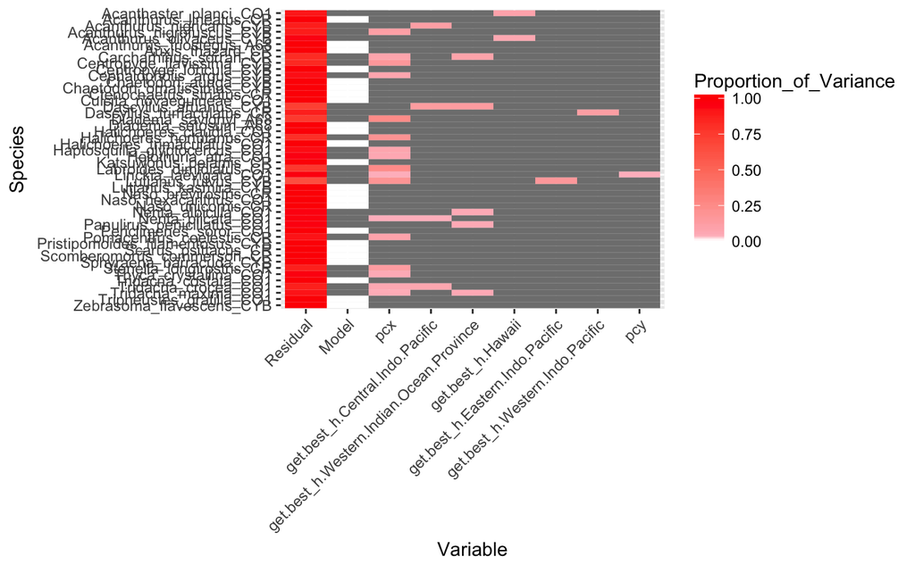

# Stacked Bars for dbRDA

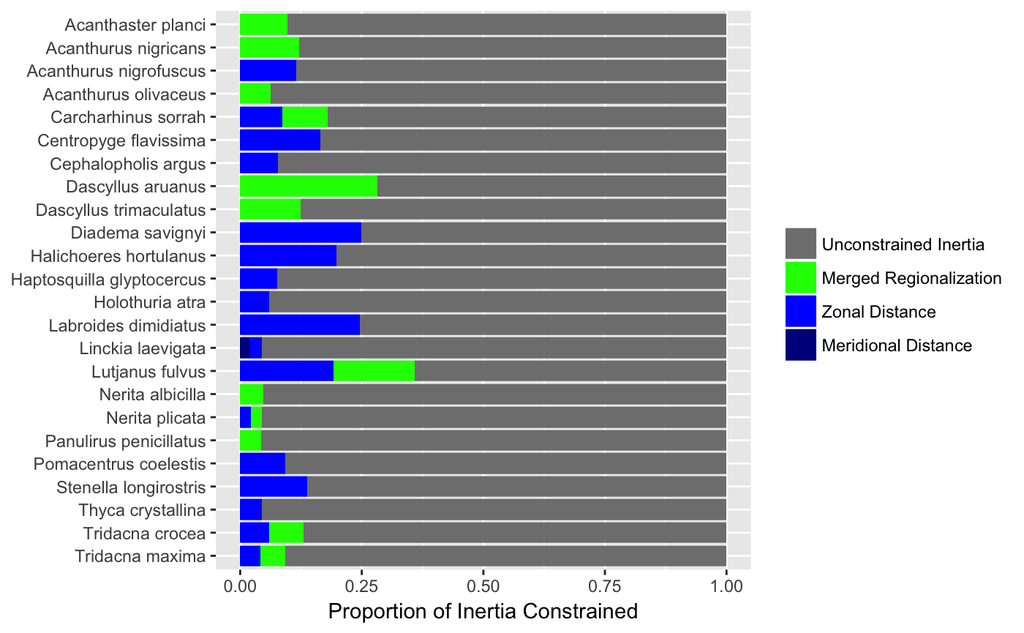

# Barrier Strength Analysis

Now I am going to come up with code to measure the mean PhiST across the merged regionalizations

## Function to pull out pairwise values for putative barriers

## Simulated Fst

I ran 1000 simulations of a 1e6 population splitting into 2 1e6 populations with either 0 or 10 migrants/generation, 10K generations ago. Couldn’t pull the .arp files into strataG, so had to run Phist analysis in Arlequin

## Randomized Fst

Randomly sort each locality for each species into two regions and calculate Fst between them.

```
 Now starting Acanthaster_planci_CO1
filtering out population samples with n < 5 and species with fewer than 2 total populations
Removed the following population samples:
converting data to various R DNA formats
```

```
unknown timezone 'zone/tz/2018e.1.0/zoneinfo/America/Los_Angeles'
```

[output not shown]

## Pull them out and plot them

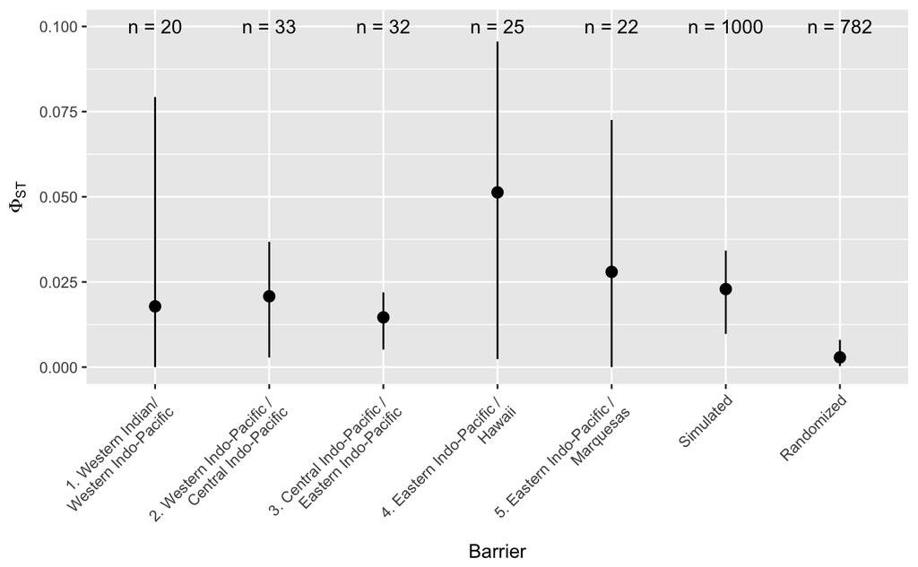